# First visualization

## Question 5

### Within tertiary education, how do earnings differ by field of study?

```r
library(readxl)
library(dplyr)
library(tidyr)
library(ggplot2)
library(scales)
library(httr)

url <- "https://raw.githubusercontent.com/siy8715-tech/PBA_Final_project/main/data/x78130.xlsx"

GET(url, write_disk(tf <- tempfile(fileext = ".xlsx")))
```

```
Response [https://raw.githubusercontent.com/siy8715-tech/PBA_Final_project/main/data/x78130.xlsx]
  Date: 2025-11-04 16:10
  Status: 200
  Content-Type: application/octet-stream
  Size: 343 kB
<ON DISK>  /var/folders/_k/qhp4g9hn5k7_dzwwdfy2fmh00000gn/T//RtmpGaQGM0/file6eb521bcc1f9.xlsx
```

```r
dt_earning_field <- read_excel(tf, sheet = 12, range = "B44:H63")

glimpse(dt_earning_field)
```

```
Rows: 19
Columns: 7
$ Country                                                            <chr> "De…
$ Notes                                                              <chr> NA,…
$ `Country & Notes`                                                  <chr> "De…
$ `Arts and humanities, social sciences, journalism and information` <dbl> -3.…
$ `Science, Technology, Engineering et Mathematics (STEM)`           <dbl> 9.2…
$ `Business, administration and law`                                 <dbl> 19.…
$ `Health and welfare`                                               <dbl> -16…
```

```r
al_country <- c(
  "France",
  "Germany",
  "Sweden",
  "Spain",
  "United States",
  "United Kingdom",
  "Japan",
  "Korea"
)

dt_earning_field <- dt_earning_field %>%
  pivot_longer(
    cols = c(
      `Arts and humanities, social sciences, journalism and information`,
      `Science, Technology, Engineering et Mathematics (STEM)`,
      `Business, administration and law`,
      `Health and welfare`
    ),
    names_to = "Field of Study",
    values_to = "Relative Earning"
  ) %>%
  select("Country",`Field of Study`,`Relative Earning`) %>%
  filter(Country %in% al_country)

glimpse(dt_earning_field)
```

```
Rows: 20
Columns: 3
$ Country            <chr> "Sweden", "Sweden", "Sweden", "Sweden", "Korea", "K…
$ `Field of Study`   <chr> "Arts and humanities, social sciences, journalism a…
$ `Relative Earning` <dbl> -11.284378, 9.539635, 18.582085, -6.299454, -11.065…
```

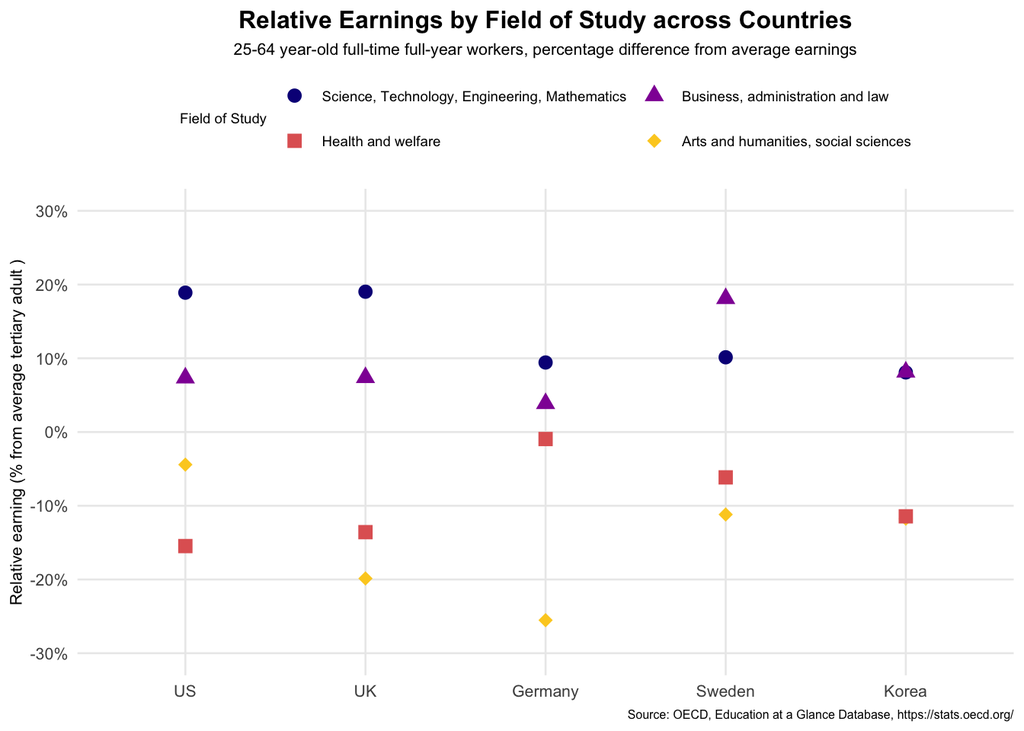

```r
dt_earning_field$Country <- factor(
  dt_earning_field$Country,
  levels = c(
    "United States", "United Kingdom",       # English-speaking
    "France", "Germany", "Sweden", "Spain",  # Europe
    "Japan", "Korea"                         # Asia
  )
)

dt_earning_field$`Field of Study` <- factor(
  dt_earning_field$`Field of Study`,
  levels = c(
    "Science, Technology, Engineering et Mathematics (STEM)",
    "Business, administration and law",
    "Health and welfare",
    "Arts and humanities, social sciences, journalism and information"
  )
)

dt_earning_field<- dt_earning_field %>%
  mutate(`Field of Study` = recode(`Field of Study`,
    "Science, Technology, Engineering et Mathematics (STEM)" = "Science, Technology, Engineering, Mathematics",
    "Arts and humanities, social sciences, journalism and information" = "Arts and humanities, social sciences"
  ),
  Country = recode(Country,
    "United States" = "US",
    "United Kingdom" ="UK"
  )
  )

earn_field <- ggplot(
  dt_earning_field,
  aes(x = Country, y = `Relative Earning`,
      shape = `Field of Study`,
      color = `Field of Study`)
) +
  scale_shape_manual(values = c(16, 17, 15, 18)) +
  geom_point(size = 3, position = position_jitter(height = 0.8, width = 0)) +
  scale_color_viridis_d(option = "C", end = 0.9) +
  labs(
    title = "Relative Earnings by Field of Study across Countries",
    subtitle = "25-64 year-old full-time full-year workers, percentage difference from average earnings",
    caption = "Source: OECD, Education at a Glance Database, https://stats.oecd.org/",
    x = NULL,
    y = "Relative earning (% from average tertiary adult )",
    color = "Field of Study",
    shape = "Field of Study"
  ) +
  theme_minimal(base_size = 10) +
  theme(
    legend.position = "top",
    legend.box = "vertical",
    legend.title = element_text(size = 7),
    legend.text  = element_text(size = 7),
    axis.text.y  = element_text(size = 8),
    axis.text.x  = element_text(size = 8),
    axis.title.y = element_text(size = 8),
    plot.caption = element_text(size = 6),
    panel.grid.minor = element_blank(),
    plot.title = element_text(face = "bold", hjust = 0.5),
    plot.subtitle = element_text(size = 8, hjust = 0.5)
  ) +
  guides(
    shape = guide_legend(nrow = 2, byrow = TRUE)
  ) +
  scale_y_continuous(
    breaks = seq(-30, 30, by = 10),
    limits = c(-30, 30),
    labels = label_percent(accuracy = 1, scale = 1)
  )

earn_field
```

Across advanced economies, STEM and business degrees yield significant positive wage premiums, especially in Anglo-Saxon markets, whereas health and arts fields tend to underperform. This highlights persistent labor-market stratification by field of study and suggests that socially essential occupations, particularly in health, may be structurally undervalued.

## Question 6

### How much wage inequality exists within the same field of study between countries?

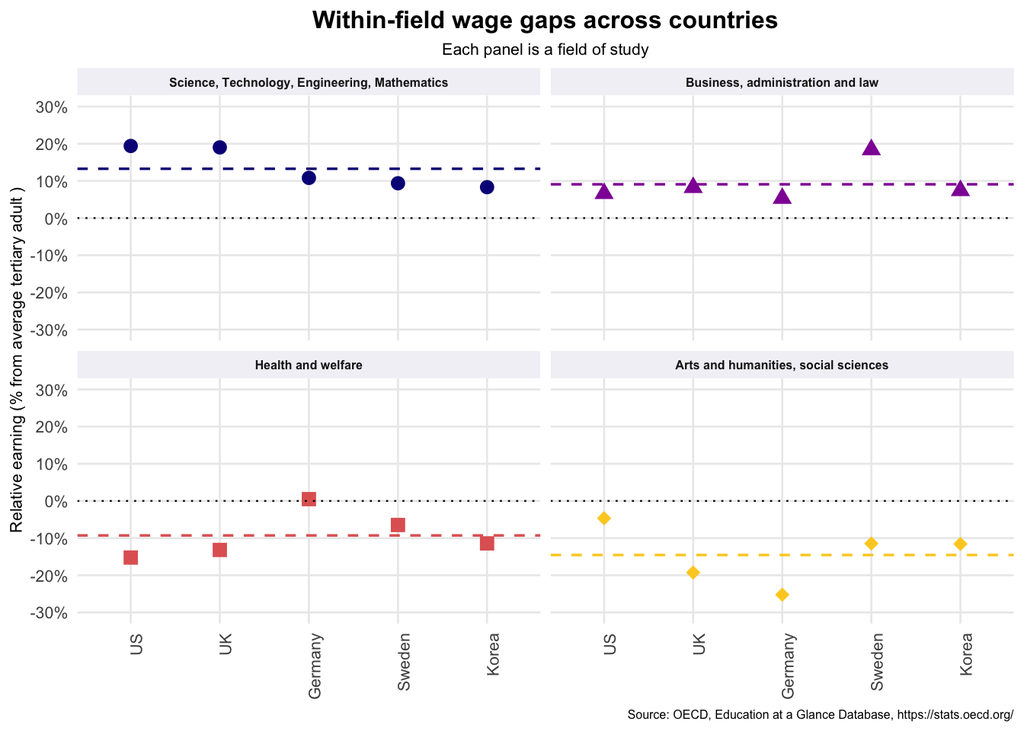

```r
field_mean <- dt_earning_field %>%
  group_by(`Field of Study`) %>%
  summarise(mu = mean(`Relative Earning`, na.rm = TRUE), .groups = "drop")

field_facet <- earn_field +
  geom_hline(yintercept = 0, linetype = "dotted", linewidth = 0.4) +
  geom_hline(data = field_mean, aes(yintercept = mu, color = `Field of Study`),
             linetype = "dashed", linewidth = 0.6, show.legend = FALSE) +
  facet_wrap(~ `Field of Study`, ncol = 2) +
  guides(color = "none", shape = "none") +
  labs(
    title = "Within-field wage gaps across countries",
    subtitle = "Each panel is a field of study"
  ) +
  theme(
    strip.text = element_text(size = 6, face = "bold"),
    strip.background = element_rect(fill = "#f2f2f7", colour = NA),
    axis.text.x = element_text(angle = 90, hjust = 1)
  )

field_facet
```

While STEM and business graduates consistently earn wage premiums across countries, the relative earnings of arts and health graduates vary more widely — ranging from modest penalties to substantial wage disadvantages depending on the country. This suggests that non-STEM labor market returns are more sensitive to national institutional and labor-market conditions, indicating greater cross-country inequality within these fields.